# Findings of 1990

The following variables are selected to see if the difference in income between men and women in 1990 vary depending on them:

1. race
2. age.start.alcohol.1984
3. womens.roles.q1
4. womens.roles.q2
5. family.size.1979

# T-Test

Use t.test to test if there is significant difference in income between male and female in 1990.

```
##
##  Welch Two Sample t-test
##
## data:  income.1990 by gender
## t = -22.674, df = 5380.8, p-value < 2.2e-16
## alternative hypothesis: true difference in means is not equal to 0
## 95 percent confidence interval:
##  -8634.298 -7260.077
## sample estimates:
## mean in group Female   mean in group Male
##             11889.45             19836.63
```

**The outcome shows that the average different in income between male and female in 1990 is 7947 dollar, with the p value 0, which is very significant.**

# Model 1

In the first model, only the data of those whose income is more than 0 but not top coded is used to do linear regression. The whole cleaned data frame is divided into two parts, one male and one female, and regression seperately.

Test if income is normally distributed using qqplot.

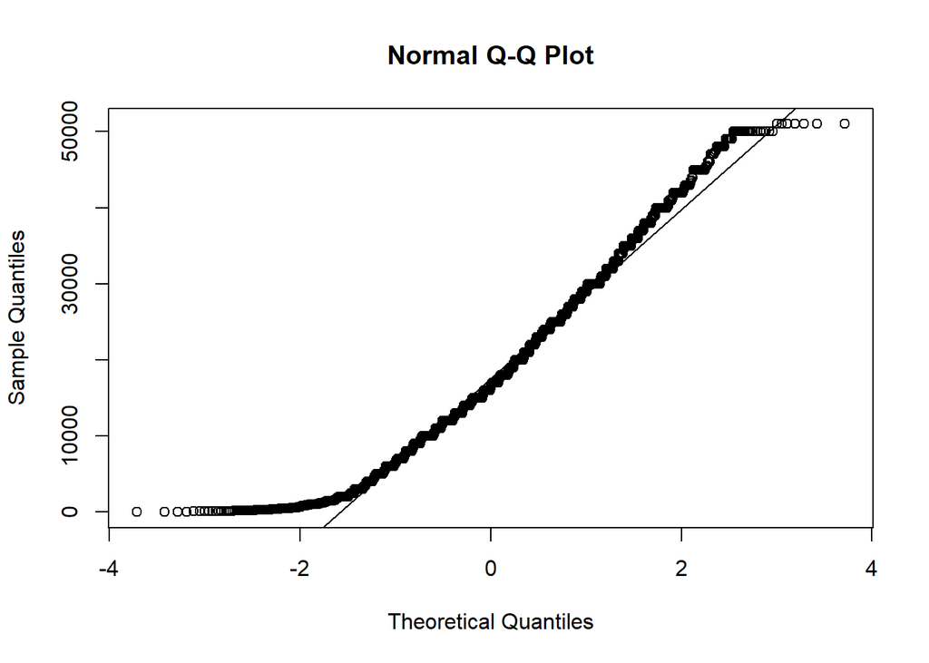

**It looks like the data is not normally distributed.**

Divide the data frame into 2 parts according to gender.

First test if there are collinear variables in male.

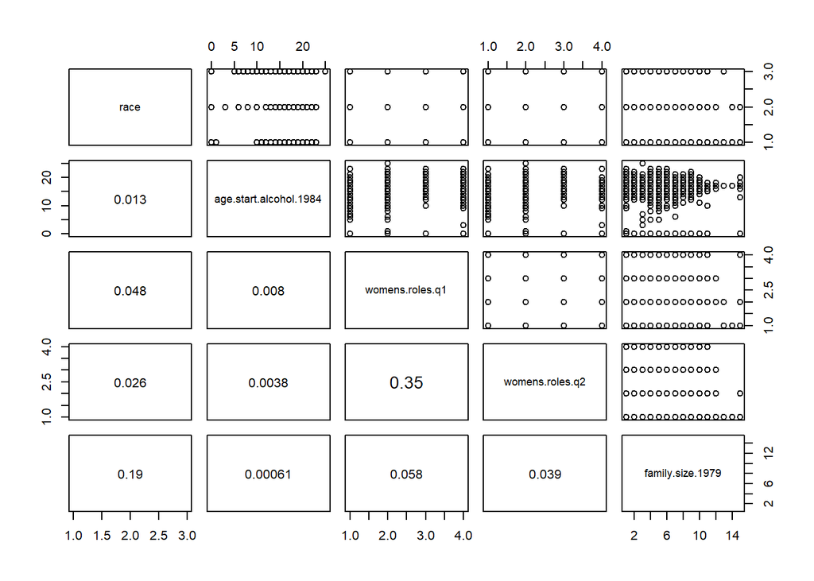

**From the plot, it can be seen that no variables are collinear in male.**

Then test female.

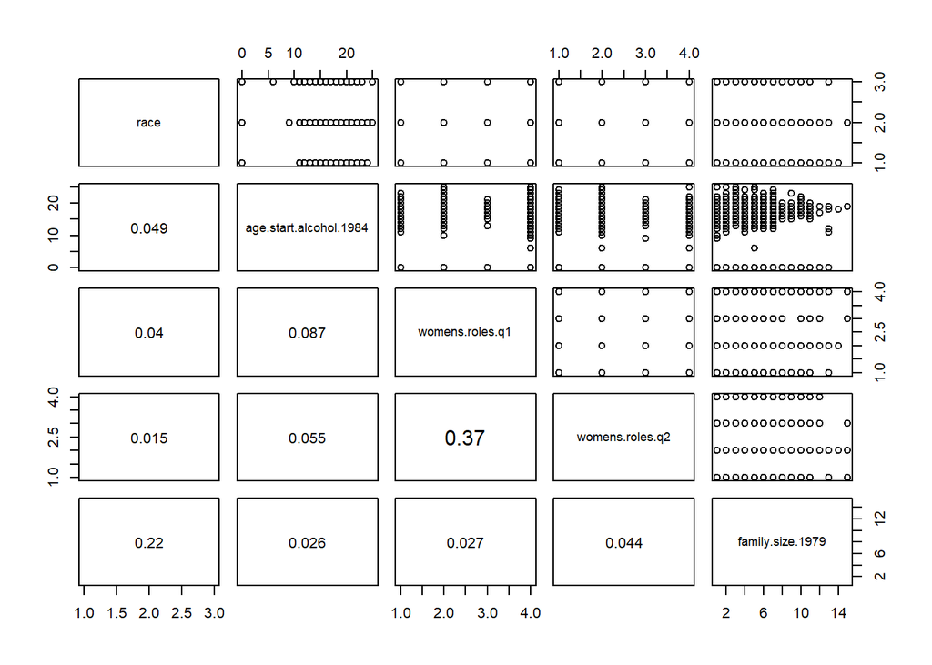

**From the plot, no variables are collinear in female.**

So it it safe to do linear regression.  
Regression summary of male:

|  | Estimate | Std. Error | t value | Pr(>\|t\|) |
| --- | --- | --- | --- | --- |
| (Intercept) | 16069.45509 | 1070.81361 | 15.0067715 | 0.0000000 |
| raceHispanic | 3438.34005 | 672.91806 | 5.1095969 | 0.0000003 |
| raceOther | 6116.44917 | 534.49923 | 11.4433265 | 0.0000000 |
| age.start.alcohol.1984 | 63.71136 | 42.77865 | 1.4893261 | 0.1365389 |
| womens.roles.q1Disagree | 707.59887 | 587.82802 | 1.2037515 | 0.2288097 |
| womens.roles.q1Strongly agree | -1114.40958 | 956.75225 | -1.1647839 | 0.2442275 |
| womens.roles.q1Strongly disagree | 466.30629 | 802.11620 | 0.5813451 | 0.5610650 |
| womens.roles.q2Disagree | 1513.92198 | 538.62064 | 2.8107389 | 0.0049847 |
| womens.roles.q2Strongly agree | 910.19148 | 969.52833 | 0.9387982 | 0.3479331 |
| womens.roles.q2Strongly disagree | 3059.39290 | 1048.68443 | 2.9173628 | 0.0035643 |
| family.size.1979 | -321.32129 | 102.81707 | -3.1251744 | 0.0017992 |

Check if the model is good.

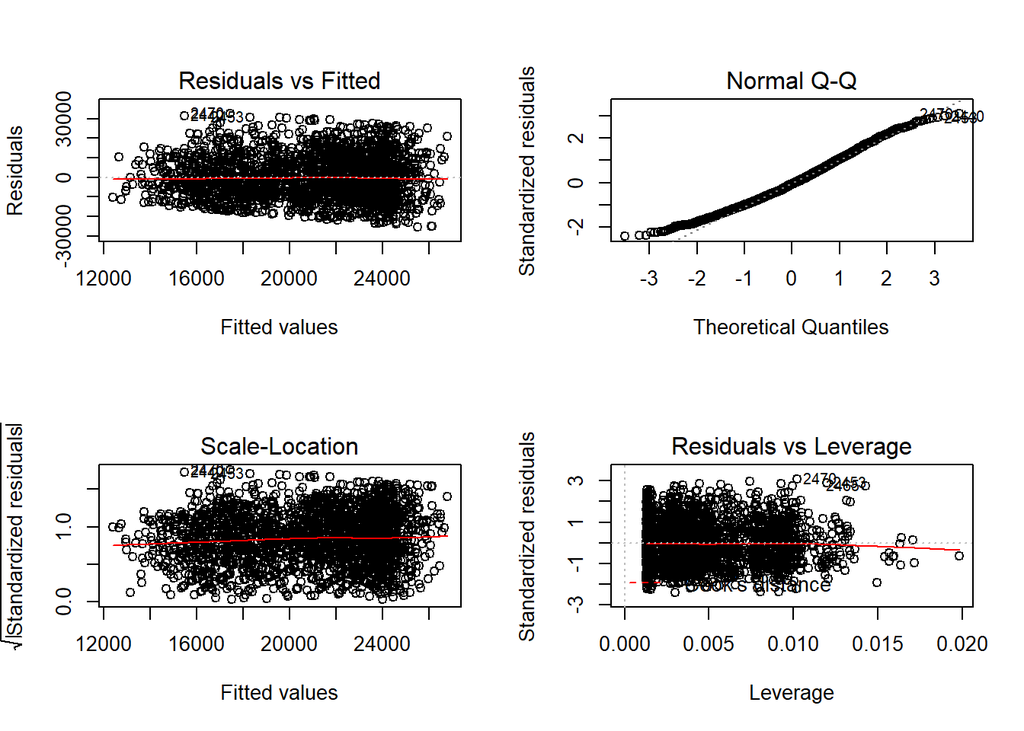

**From the 4 plots, it can be seen that the model is quite good because:**  
**In the 1st plot, data is distributed randomly;**  
**In the 2nd plot, data is nearly a straight line from the lower left corner to the upper right corner;**  
**In the 3rd plot, the red line is flat;**  
**In the 4th plot, very few data exceeds 3 or -3;**

Regression summary of female:

|  | Estimate | Std. Error | t value | Pr(>\|t\|) |
| --- | --- | --- | --- | --- |
| (Intercept) | 8980.12823 | 1029.72863 | 8.7208688 | 0.0000000 |
| raceHispanic | 2001.24342 | 638.87611 | 3.1324437 | 0.0017565 |
| raceOther | 2338.13954 | 488.94325 | 4.7820264 | 0.0000019 |
| age.start.alcohol.1984 | 55.32895 | 27.81039 | 1.9895061 | 0.0467693 |
| womens.roles.q1Disagree | 1323.32927 | 748.83891 | 1.7671748 | 0.0773380 |
| womens.roles.q1Strongly agree | 214.05456 | 1465.44193 | 0.1460683 | 0.8838809 |
| womens.roles.q1Strongly disagree | 3497.11698 | 785.37855 | 4.4527788 | 0.0000089 |
| womens.roles.q2Disagree | 2156.92985 | 581.76253 | 3.7075778 | 0.0002144 |
| womens.roles.q2Strongly agree | -659.52291 | 1153.91888 | -0.5715505 | 0.5676851 |
| womens.roles.q2Strongly disagree | 3321.87201 | 740.39181 | 4.4866407 | 0.0000076 |
| family.size.1979 | -61.70880 | 98.23371 | -0.6281835 | 0.5299491 |

Check if the model is good.

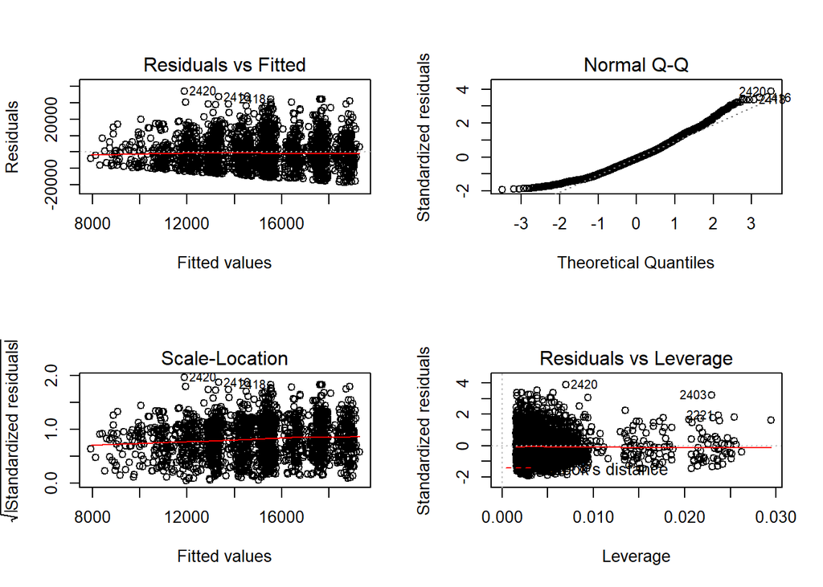

**From the 4 plots, the model is quite good for similar reasons**

**Significant variables (with p value <= 0.05) of male are shown below:**

|  | Estimate | Std. Error | t value | Pr(>\|t\|) |
| --- | --- | --- | --- | --- |
| (Intercept) | 16069.4551 | 1070.8136 | 15.006771 | 0.0000000 |
| raceHispanic | 3438.3401 | 672.9181 | 5.109597 | 0.0000003 |
| raceOther | 6116.4492 | 534.4992 | 11.443326 | 0.0000000 |
| womens.roles.q2Disagree | 1513.9220 | 538.6206 | 2.810739 | 0.0049847 |
| womens.roles.q2Strongly disagree | 3059.3929 | 1048.6844 | 2.917363 | 0.0035643 |
| family.size.1979 | -321.3213 | 102.8171 | -3.125174 | 0.0017992 |

**Significant variables (with p value <= 0.05) of female are shown below:**

|  | Estimate | Std. Error | t value | Pr(>\|t\|) |
| --- | --- | --- | --- | --- |
| (Intercept) | 8980.12823 | 1029.72863 | 8.720869 | 0.0000000 |
| raceHispanic | 2001.24342 | 638.87611 | 3.132444 | 0.0017565 |
| raceOther | 2338.13954 | 488.94325 | 4.782026 | 0.0000019 |
| age.start.alcohol.1984 | 55.32895 | 27.81039 | 1.989506 | 0.0467693 |
| womens.roles.q1Strongly disagree | 3497.11698 | 785.37855 | 4.452779 | 0.0000089 |
| womens.roles.q2Disagree | 2156.92985 | 581.76253 | 3.707578 | 0.0002144 |
| womens.roles.q2Strongly disagree | 3321.87201 | 740.39181 | 4.486641 | 0.0000076 |

# Model 2

In the second model, data of those whose income is more than 0 is used to create a logistic variable of whether the responder is of high income (whether the responder’s income is top coded), and do logistic regression.

Regression summary of male:

|  | Estimate | Std. Error | t value | Pr(>\|t\|) |
| --- | --- | --- | --- | --- |
| (Intercept) | 0.0232655 | 0.0173180 | 1.3434302 | 0.1792613 |
| raceHispanic | 0.0193816 | 0.0109039 | 1.7774958 | 0.0756148 |
| raceOther | 0.0193440 | 0.0086772 | 2.2292826 | 0.0258885 |
| age.start.alcohol.1984 | 0.0002533 | 0.0006895 | 0.3673940 | 0.7133580 |
| womens.roles.q1Disagree | -0.0054720 | 0.0095100 | -0.5753914 | 0.5650812 |
| womens.roles.q1Strongly agree | -0.0078859 | 0.0154971 | -0.5088675 | 0.6108924 |
| womens.roles.q1Strongly disagree | -0.0071950 | 0.0129689 | -0.5547903 | 0.5790904 |
| womens.roles.q2Disagree | 0.0094989 | 0.0087398 | 1.0868545 | 0.2772116 |
| womens.roles.q2Strongly agree | -0.0041088 | 0.0157542 | -0.2608046 | 0.7942659 |
| womens.roles.q2Strongly disagree | 0.0419373 | 0.0167672 | 2.5011458 | 0.0124462 |
| family.size.1979 | -0.0027735 | 0.0016603 | -1.6704514 | 0.0949621 |

Regression summary of female:

|  | Estimate | Std. Error | z value | Pr(>\|z\|) |
| --- | --- | --- | --- | --- |
| (Intercept) | -5.2453641 | 1.4452003 | -3.6295067 | 0.0002840 |
| raceHispanic | -0.1686192 | 1.2310081 | -0.1369766 | 0.8910493 |
| raceOther | 1.3009356 | 0.7653726 | 1.6997415 | 0.0891796 |
| age.start.alcohol.1984 | -0.0131371 | 0.0332578 | -0.3950072 | 0.6928376 |
| womens.roles.q1Disagree | -0.1682764 | 1.1450708 | -0.1469572 | 0.8831658 |
| womens.roles.q1Strongly agree | 1.8586490 | 1.4373678 | 1.2930922 | 0.1959792 |
| womens.roles.q1Strongly disagree | 0.9494396 | 1.1118273 | 0.8539453 | 0.3931353 |
| womens.roles.q2Disagree | -0.2866689 | 0.7096172 | -0.4039768 | 0.6862298 |
| womens.roles.q2Strongly agree | -15.0993866 | 1029.7415894 | -0.0146633 | 0.9883008 |
| womens.roles.q2Strongly disagree | 0.0643698 | 0.8016594 | 0.0802957 | 0.9360021 |
| family.size.1979 | -0.1556328 | 0.1363999 | -1.1410038 | 0.2538683 |

**Significant variables (with p value <= 0.05) of male are shown below:**

|  | Estimate | Std. Error | t value | Pr(>\|t\|) |
| --- | --- | --- | --- | --- |
| raceOther | 0.0193440 | 0.0086772 | 2.229283 | 0.0258885 |
| womens.roles.q2Strongly disagree | 0.0419373 | 0.0167672 | 2.501146 | 0.0124462 |

**There are no significant variables (with p value <= 0.05) of female**

**It is found that whether one has top 2% income in 1990 vary depending on:**  
**1. Race. For male of other race compared to black, the odds of having an income of top 2% increase by a factor of 1.0195323 with a p value of 0.0258885, while there is no significant relationship between female of other race and black female.**  
**2. Whether the responder agrees that a wife who carries out her full family responsibilities does not have time for outside employment (women.role.2). For male who strongly disagree with it compared to male who agree with it, the odds of having an income of top 2% increase by a factor of 1.0428291 with a p value of 0.0124462, while there is no significant relationship for that of female.**

# Model 3

In the third model, every data is used to create a logistic variable of whether the responder has income (whether the income is more than 0), and do logistic regression.

Regression summary of male:

|  | Estimate | Std. Error | t value | Pr(>\|t\|) |
| --- | --- | --- | --- | --- |
| (Intercept) | 0.8301824 | 0.0286709 | 28.9555607 | 0.0000000 |
| raceHispanic | 0.0723671 | 0.0180810 | 4.0023935 | 0.0000644 |
| raceOther | 0.0901978 | 0.0143301 | 6.2942826 | 0.0000000 |
| age.start.alcohol.1984 | 0.0024101 | 0.0011422 | 2.1100922 | 0.0349433 |
| womens.roles.q1Disagree | -0.0217989 | 0.0159669 | -1.3652512 | 0.1722893 |
| womens.roles.q1Strongly agree | 0.0230022 | 0.0261429 | 0.8798619 | 0.3790134 |
| womens.roles.q1Strongly disagree | -0.0116231 | 0.0218201 | -0.5326809 | 0.5942988 |
| womens.roles.q2Disagree | -0.0101548 | 0.0146777 | -0.6918541 | 0.4890892 |
| womens.roles.q2Strongly agree | -0.0502729 | 0.0259381 | -1.9381832 | 0.0527063 |
| womens.roles.q2Strongly disagree | -0.0216923 | 0.0281133 | -0.7716030 | 0.4404179 |
| family.size.1979 | -0.0033344 | 0.0027443 | -1.2150571 | 0.2244519 |

Regression summary of female:

|  | Estimate | Std. Error | z value | Pr(>\|z\|) |
| --- | --- | --- | --- | --- |
| (Intercept) | 0.5653226 | 0.2144548 | 2.6360921 | 0.0083867 |
| raceHispanic | -0.1786551 | 0.1348756 | -1.3245913 | 0.1853068 |
| raceOther | 0.2519119 | 0.1117685 | 2.2538723 | 0.0242042 |
| age.start.alcohol.1984 | -0.0004337 | 0.0062643 | -0.0692313 | 0.9448055 |
| womens.roles.q1Disagree | 0.3912906 | 0.1497601 | 2.6127824 | 0.0089808 |
| womens.roles.q1Strongly agree | -0.3558650 | 0.2555849 | -1.3923549 | 0.1638150 |
| womens.roles.q1Strongly disagree | 0.5727625 | 0.1621890 | 3.5314513 | 0.0004133 |
| womens.roles.q2Disagree | 0.2308686 | 0.1235451 | 1.8686995 | 0.0616646 |
| womens.roles.q2Strongly agree | -0.0817145 | 0.2253577 | -0.3625992 | 0.7169043 |
| womens.roles.q2Strongly disagree | 0.2442149 | 0.1684947 | 1.4493925 | 0.1472280 |
| family.size.1979 | 0.0259344 | 0.0218909 | 1.1847099 | 0.2361322 |

**Significant variables (with p value <= 0.05) of male are shown below:**

|  | Estimate | Std. Error | t value | Pr(>\|t\|) |
| --- | --- | --- | --- | --- |
| (Intercept) | 0.8301824 | 0.0286709 | 28.955561 | 0.0000000 |
| raceHispanic | 0.0723671 | 0.0180810 | 4.002394 | 0.0000644 |
| raceOther | 0.0901978 | 0.0143301 | 6.294283 | 0.0000000 |
| age.start.alcohol.1984 | 0.0024101 | 0.0011422 | 2.110092 | 0.0349433 |

**Significant variables (with p value <= 0.05) of female are shown below:**

|  | Estimate | Std. Error | z value | Pr(>\|z\|) |
| --- | --- | --- | --- | --- |
| (Intercept) | 0.5653226 | 0.2144548 | 2.636092 | 0.0083867 |
| raceOther | 0.2519119 | 0.1117685 | 2.253872 | 0.0242042 |
| womens.roles.q1Disagree | 0.3912906 | 0.1497601 | 2.612782 | 0.0089808 |
| womens.roles.q1Strongly disagree | 0.5727625 | 0.1621890 | 3.531451 | 0.0004133 |

# Interaction Model

Here we use interaction model to study how the difference in income between male and female varies depending on other factors. Three different models are introduced to respectively depict three income variables in different years.

For the income in 1990, all the variables mentioned above related to year 1990 are taken into consideration here at first. We select the variabels needed into `clean.nlsy.income1990.4`. For the income of 1990, we exclude the top 2% and zero income data.

To test whether the income.1990 in clean.nlsy.income1990.4 is normally distributed, `qqmorm()` and `qqline()` are used here.

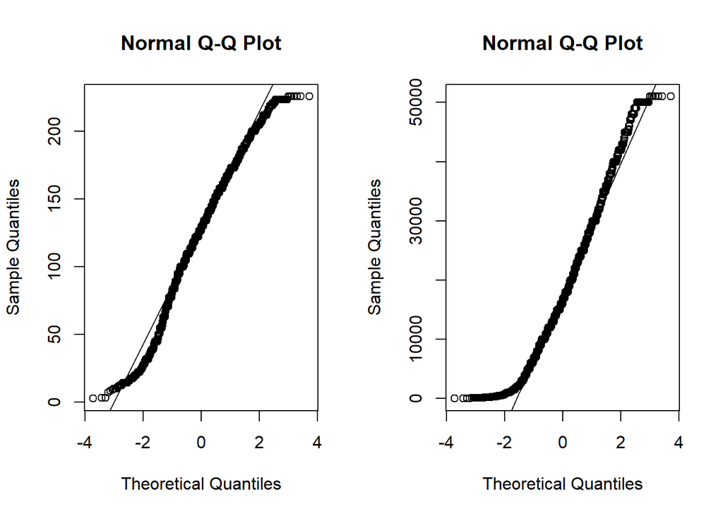

From the figure above, `income.1990^0.5` (left one) is more normally distributed than `income.1990` (right one). Therefore, `income.1990^0.5` is used in this interaction regression model.

Make each variable interact with `gender`. The summary and plots are as follows:

```
##
## Call:
## lm(formula = income.1990^0.5 ~ womens.roles.q1 * gender + womens.roles.q2 *
##     gender + race * gender + family.size.1979 * gender, data = clean.nlsy.income1990.4)
##
## Residuals:
##      Min       1Q   Median       3Q      Max
## -150.477  -25.327    3.481   28.936  121.744
##
## Coefficients:
##                                             Estimate Std. Error t value
## (Intercept)                                  89.9421     4.0592  22.157
## womens.roles.q1Disagree                       5.9501     3.0710   1.938
## womens.roles.q1Strongly agree                -3.4367     5.6721  -0.606
## womens.roles.q1Strongly disagree             16.1005     3.2233   4.995
## genderMale                                   32.8462     5.2145   6.299
## womens.roles.q2Disagree                       9.1186     2.4077   3.787
## womens.roles.q2Strongly agree                -2.0865     4.7348  -0.441
## womens.roles.q2Strongly disagree             14.0967     3.0738   4.586
## raceHispanic                                  8.5980     2.5906   3.319
## raceOther                                    10.8028     2.0081   5.380
## family.size.1979                             -0.1883     0.4009  -0.470
## womens.roles.q1Disagree:genderMale           -1.8001     3.7915  -0.475
## womens.roles.q1Strongly agree:genderMale     -1.2483     6.7131  -0.186
## womens.roles.q1Strongly disagree:genderMale -12.0110     4.4522  -2.698
## genderMale:womens.roles.q2Disagree           -5.1473     3.1576  -1.630
## genderMale:womens.roles.q2Strongly agree      5.9721     5.9949   0.996
## genderMale:womens.roles.q2Strongly disagree  -7.1355     5.0182  -1.422
## genderMale:raceHispanic                       4.0701     3.6252   1.123
## genderMale:raceOther                         13.0976     2.8500   4.596
## genderMale:family.size.1979                  -0.9823     0.5606  -1.752
##                                             Pr(>|t|)
## (Intercept)                                  < 2e-16 ***
## womens.roles.q1Disagree                     0.052740 .
## womens.roles.q1Strongly agree               0.544608
## womens.roles.q1Strongly disagree            6.09e-07 ***
## genderMale                                  3.26e-10 ***
## womens.roles.q2Disagree                     0.000154 ***
## womens.roles.q2Strongly agree               0.659461
## womens.roles.q2Strongly disagree            4.63e-06 ***
## raceHispanic                                0.000910 ***
## raceOther                                   7.81e-08 ***
## family.size.1979                            0.638672
## womens.roles.q1Disagree:genderMale          0.634963
## womens.roles.q1Strongly agree:genderMale    0.852490
## womens.roles.q1Strongly disagree:genderMale 0.007004 **
## genderMale:womens.roles.q2Disagree          0.103144
## genderMale:womens.roles.q2Strongly agree    0.319205
## genderMale:womens.roles.q2Strongly disagree 0.155119
## genderMale:raceHispanic                     0.261610
## genderMale:raceOther                        4.43e-06 ***
## genderMale:family.size.1979                 0.079822 .
## ---
## Signif. codes:  0 '***' 0.001 '**' 0.01 '*' 0.05 '.' 0.1 ' ' 1
##
## Residual standard error: 41.68 on 4827 degrees of freedom
##   (56 observations deleted due to missingness)
## Multiple R-squared:  0.1343, Adjusted R-squared:  0.1309
## F-statistic: 39.43 on 19 and 4827 DF,  p-value: < 2.2e-16
```

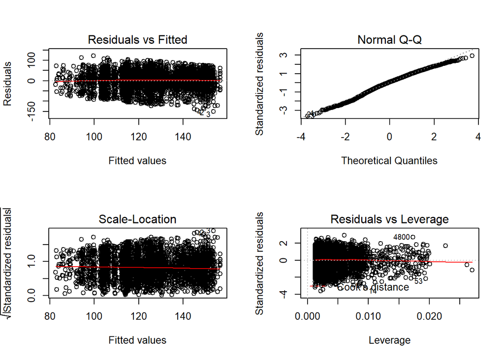

[output not shown]

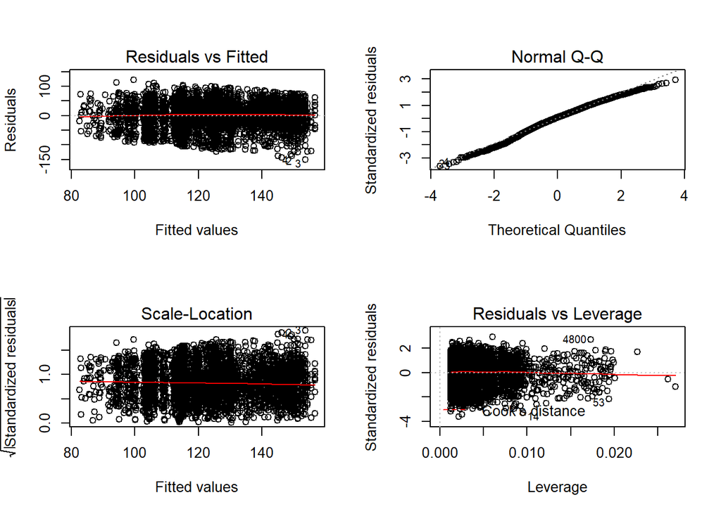

Be careful that the dependant variable here is `income.1990^0.5` rather than `income.1990`, so the interperation of the coefficients will be different.

**According to the results, generally, the `income.1990^0.5` of male will be 32.85 higher than female. Therefore, the income difference between male and female in 1990 is 6987.39**

There are two interaction terms indicate the significant association to the difference of income between male and female.